# Part 1

### 1. Write a program to calculate the area of a circle. The program should ask for the appropriate input and print the resulting area on the screen. (4 points)

a. Input text: Please enter the radius of the circle.  
b. If the user enters a value of 5. The output should be: The area of the circle is 78.54  
c. This program should indicate that the input is invalid if the user enters a character instead of a number as input. For instance if the user enters a value of ‘a’ instead of 5 in the previous example the program should prompt: Invalid input, please enter a number

```python
def area_of_a_circle(user_in):
    if user_in.isdigit():
        R = int(user_in)
        PI = 3.1416
        return PI * R * R
    else:
        return 'Invalid input, please enter a number'

user_input = input("Please enter the radius of the circle: ")
print(area_of_a_circle(user_input))
```

```
Please enter the radius of the circle: 5
78.54
```

### 2. Write a program which will take two lists X & Y as input and it will return true along with the common element if they have one or more common elements.(4 points)

a. Input list: X=[1,2,3,4,5] & Y=[5,6,7,8,9]  
b. Output: The similar element is

```python
X = [1,2,3,4,5]
Y = [5,6,7,8,9]

def check_common_elements(list_1, list_2):
    common_elements = []
    for i in list_1:
        if i in list_2:
            common_elements.append(i)

    if common_elements:
        common_elements = ','.join(map(str, common_elements))
        print(f"The similar element is: {str(common_elements)}")
        return True
    else:
        return False

print(check_common_elements(X, Y))
```

```
The similar element is: 5
True
```

#### 3. Given two sets s1={5,8,3,6} & s2={1,5.7,8.9} Write a program to check whether the two sets are disjoint (have no common elements) and return 'True' if there are no common elements. (3 points)

```python
s1 = {5,8,3,6}
s2 = {1,5,7,8,9}

result = s1.isdisjoint(s2)
print(result)
```

```
False
```

### 4. Write a program to check whether a given number is a prime number or not?. Check for number 3 and 4. (4 points)

```python
num_1 = 3
num_2 = 4

def check_prime(num):
    check = 0
    if num > 1:
        for i in range(2, num):
            if (num % i) == 0:
                check = 1
                break
    if check > 0:
        print(num, "is not a prime number")
    else:
        print(num, "is a prime number")

check_prime(num_1)
check_prime(num_2)
```

```
3 is a prime number
4 is not a prime number
```

### 5. Create an encrypter in python based on the ceaser cipher. It is a substitution cipher where each character of the original text is shifted by a certain number to another character in the alphabet.

a. 5.1 Write a function which will encrypt a given text. The function would require 2 arguments – the input text to be encrypted and a key. (5 points)  
b. 5.2 Similarly create a decrypter which can decode the encrypted text when provided with the input text and key. (5 points)  
c. For eg: Given the input text ‘hello’ and the key 3, the resulting encrypted text would be ‘khoor’. Here you can see that every character in the string hello is shifted by 3 characters. ‘h’ has shifted to ‘k’, ‘e’ has shifted to ‘h’ and so on. If a key of 5 were used, the resulting string would be ‘mjqqt’.  
d. Example: encrypt(‘hello world!’, 3):- ‘khoor zruog!’  
e. Example: decrypt(‘khoor zruog!’, 3):- ‘hello world!’

```python
# word = input('Enter the plain text: ')
word = 'hello world!'

def cipher_encrypt(word, key):
    results = ''
    if type(key) != int:
        return 'The key must be an integer'
    else:
        for i in word:
            # Ignore number, special characters and Spaces
            if i.isalpha() == False:
                results += i
            else:
                # ord function to return the number of char
                results += chr(ord(i) + int(key))
    return results

cipher_encrypt(word, 3)
# cipher_encrypt(word, 5)
```

```
'khoor zruog!'
```

```python
encrypted_word = 'khoor zruog!'

def cipher_decrypt(word, key):
    results = ''
    if type(key) != int:
        return 'The key must be an integer'
    else:
        for i in word:
            # Ignore number, special characters and Spaces
            if i.isalpha() == False:
                results += i
            else:
                # ord function to return the number of char
                results += chr(ord(i) - int(key))
    return results

cipher_decrypt(encrypted_word, 3)
```

```
'hello world!'
```

# Part 2

### 1. Import necessary libraries and read the provided dataset (online_sales.csv). (1 point)

```python
import pandas as pd
import seaborn as sns   # Why sns?  It's a reference to The West Wing
import matplotlib.pyplot as plt  # seaborn is based on matplotlib
sns.set(color_codes=True) # adds a nice background to the graphs
%matplotlib inline
import os
```

```python
df = pd.read_csv('online_sales.csv')
df
```

|  | InvoiceNo | StockCode | Description | Quantity | InvoiceDate | UnitPrice | CustomerID | Country |
| --- | --- | --- | --- | --- | --- | --- | --- | --- |
| 0 | 536365 | 85123A | WHITE HANGING HEART T-LIGHT HOLDER | 6 | 12/1/10 8:26 | 2.55 | 17850.0 | United Kingdom |
| 1 | 536365 | 71053 | WHITE METAL LANTERN | 6 | 12/1/10 8:26 | 3.39 | 17850.0 | United Kingdom |
| 2 | 536365 | 84406B | CREAM CUPID HEARTS COAT HANGER | 8 | 12/1/10 8:26 | 2.75 | 17850.0 | United Kingdom |
| 3 | 536365 | 84029G | KNITTED UNION FLAG HOT WATER BOTTLE | 6 | 12/1/10 8:26 | 3.39 | 17850.0 | United Kingdom |
| 4 | 536365 | 84029E | RED WOOLLY HOTTIE WHITE HEART. | 6 | 12/1/10 8:26 | 3.39 | 17850.0 | United Kingdom |
| ... | ... | ... | ... | ... | ... | ... | ... | ... |
| 240002 | 558077 | 47590A | BLUE HAPPY BIRTHDAY BUNTING | 12 | 6/26/11 10:59 | 5.45 | 13408.0 | United Kingdom |
| 240003 | 558077 | 82600 | NO SINGING METAL SIGN | 12 | 6/26/11 10:59 | 2.10 | 13408.0 | United Kingdom |
| 240004 | 558077 | 85123A | WHITE HANGING HEART T-LIGHT HOLDER | 32 | 6/26/11 10:59 | 2.55 | 13408.0 | United Kingdom |
| 240005 | 558077 | 22746 | POPPY'S PLAYHOUSE LIVINGROOM | 12 | 6/26/11 10:59 | 2.10 | 13408.0 | United Kingdom |
| 240006 | 558077 | 23251 | VINTAGE RED ENAMEL TRIM MUG | 12 | 6/26/11 10:59 | 1.25 | 13408.0 | Unit |

240007 rows × 8 columns

### 2. Check top 5 and random 5 samples of the dataframe. (1 point)

```python
df.head()
```

|  | InvoiceNo | StockCode | Description | Quantity | InvoiceDate | UnitPrice | CustomerID | Country |
| --- | --- | --- | --- | --- | --- | --- | --- | --- |
| 0 | 536365 | 85123A | WHITE HANGING HEART T-LIGHT HOLDER | 6 | 12/1/10 8:26 | 2.55 | 17850.0 | United Kingdom |
| 1 | 536365 | 71053 | WHITE METAL LANTERN | 6 | 12/1/10 8:26 | 3.39 | 17850.0 | United Kingdom |
| 2 | 536365 | 84406B | CREAM CUPID HEARTS COAT HANGER | 8 | 12/1/10 8:26 | 2.75 | 17850.0 | United Kingdom |
| 3 | 536365 | 84029G | KNITTED UNION FLAG HOT WATER BOTTLE | 6 | 12/1/10 8:26 | 3.39 | 17850.0 | United Kingdom |
| 4 | 536365 | 84029E | RED WOOLLY HOTTIE WHITE HEART. | 6 | 12/1/10 8:26 | 3.39 | 17850.0 | United Kingdom |

```python
df.sample(n=5)
```

|  | InvoiceNo | StockCode | Description | Quantity | InvoiceDate | UnitPrice | CustomerID | Country |
| --- | --- | --- | --- | --- | --- | --- | --- | --- |
| 136775 | 547985 | 22078 | RIBBON REEL LACE DESIGN | 10 | 3/29/11 8:43 | 2.10 | 16455.0 | United Kingdom |
| 49181 | 540506 | 85114C | RED ENCHANTED FOREST PLACEMAT | 1 | 1/9/11 11:12 | 1.65 | 17796.0 | United Kingdom |
| 37890 | 539487 | 21843 | RED RETROSPOT CAKE STAND | 2 | 12/20/10 9:22 | 10.95 | 16153.0 | United Kingdom |
| 207184 | 554978 | 22728 | ALARM CLOCK BAKELIKE PINK | 2 | 5/29/11 11:05 | 3.75 | 16889.0 | United Kingdom |
| 185607 | 552822 | 22278 | OVERNIGHT BAG VINTAGE ROSE PAISLEY | 1 | 5/11/11 12:59 | 4.95 | 15521.0 | United Kingdom |

### 3. Check info of the dataframe and write your observations. Comment on data types and shape of the dataset. (1 points)

```python
df.info()
```

```
<class 'pandas.core.frame.DataFrame'>
RangeIndex: 240007 entries, 0 to 240006
Data columns (total 8 columns):
 #   Column       Non-Null Count   Dtype
---  ------       --------------   -----
 0   InvoiceNo    240007 non-null  object
 1   StockCode    240007 non-null  object
 2   Description  239106 non-null  object
 3   Quantity     240007 non-null  int64
 4   InvoiceDate  240007 non-null  object
 5   UnitPrice    240007 non-null  float64
 6   CustomerID   172782 non-null  float64
 7   Country      240007 non-null  object
dtypes: float64(2), int64(1), object(5)
memory usage: 14.6+ MB
```

1- I found that the there is 240007 rows and there is some values of is missing in the following columns (Description, CustomerID )  
2- There is Categorical columns (Country, InvoiceNo, CustomerID, StockCode)  
3- There is numeric columns (UnitPrice, Quantity)

```python
df.shape
```

```
(240007, 8)
```

There is 240007 row and 8 columns in the Dataframe

### 4. Check for null values and report the percentage of null values of each column. And drop the rows having null values in it. (1 points)

```python
df.isnull().sum() * 100 / len(df)
```

```
InvoiceNo       0.000000
StockCode       0.000000
Description     0.375406
Quantity        0.000000
InvoiceDate     0.000000
UnitPrice       0.000000
CustomerID     28.009600
Country         0.000000
dtype: float64
```

```python
df = df.dropna() #drop null values
```

### 5. Check statistical summary of the dataset. (1 point)

```python
df.describe().T
```

|  | count | mean | std | min | 25% | 50% | 75% | max |
| --- | --- | --- | --- | --- | --- | --- | --- | --- |
| Quantity | 172782.0 | 12.244835 | 257.898235 | -74215.0 | 2.00 | 5.00 | 12.00 | 74215.0 |
| UnitPrice | 172782.0 | 3.793566 | 101.069930 | 0.0 | 1.25 | 1.95 | 3.75 | 38970.0 |
| CustomerID | 172782.0 | 15274.819941 | 1725.093177 | 12346.0 | 13842.00 | 15132.00 | 16814.00 | 18287.0 |

### 6. Drop the instances having quantity less than zero. (1 point)

```python
df = df.drop(df[df['Quantity'] < 0].index, axis=0)
df
```

|  | InvoiceNo | StockCode | Description | Quantity | InvoiceDate | UnitPrice | CustomerID | Country |
| --- | --- | --- | --- | --- | --- | --- | --- | --- |
| 0 | 536365 | 85123A | WHITE HANGING HEART T-LIGHT HOLDER | 6 | 12/1/10 8:26 | 2.55 | 17850.0 | United Kingdom |
| 1 | 536365 | 71053 | WHITE METAL LANTERN | 6 | 12/1/10 8:26 | 3.39 | 17850.0 | United Kingdom |
| 2 | 536365 | 84406B | CREAM CUPID HEARTS COAT HANGER | 8 | 12/1/10 8:26 | 2.75 | 17850.0 | United Kingdom |
| 3 | 536365 | 84029G | KNITTED UNION FLAG HOT WATER BOTTLE | 6 | 12/1/10 8:26 | 3.39 | 17850.0 | United Kingdom |
| 4 | 536365 | 84029E | RED WOOLLY HOTTIE WHITE HEART. | 6 | 12/1/10 8:26 | 3.39 | 17850.0 | United Kingdom |
| ... | ... | ... | ... | ... | ... | ... | ... | ... |
| 240002 | 558077 | 47590A | BLUE HAPPY BIRTHDAY BUNTING | 12 | 6/26/11 10:59 | 5.45 | 13408.0 | United Kingdom |
| 240003 | 558077 | 82600 | NO SINGING METAL SIGN | 12 | 6/26/11 10:59 | 2.10 | 13408.0 | United Kingdom |
| 240004 | 558077 | 85123A | WHITE HANGING HEART T-LIGHT HOLDER | 32 | 6/26/11 10:59 | 2.55 | 13408.0 | United Kingdom |
| 240005 | 558077 | 22746 | POPPY'S PLAYHOUSE LIVINGROOM | 12 | 6/26/11 10:59 | 2.10 | 13408.0 | United Kingdom |
| 240006 | 558077 | 23251 | VINTAGE RED ENAMEL TRIM MUG | 12 | 6/26/11 10:59 | 1.25 | 13408.0 | Unit |

168675 rows × 8 columns

### 7. Check unique values of the country and report the name of the country that has the highest number of instances. (2 points)

```python
df['Country'].value_counts()
```

```
United Kingdom          150046
Germany                   3958
France                    3562
EIRE                      2650
Netherlands               1139
Spain                     1131
Belgium                    914
Switzerland                697
Australia                  630
Portugal                   610
Norway                     368
Channel Islands            363
Cyprus                     350
Finland                    307
Italy                      299
Japan                      230
Sweden                     195
Denmark                    184
Poland                     180
Austria                    124
Singapore                  113
Iceland                    102
Greece                      85
Unspecified                 72
Canada                      68
Lebanon                     45
Malta                       45
Lithuania                   35
Brazil                      32
European Community          31
United Arab Emirates        30
USA                         22
Bahrain                     17
Israel                      16
Czech Republic              15
Saudi Arabia                 9
Unit                         1
Name: Country, dtype: int64
```

```python
df['Country'].value_counts().idxmax() #the country that has the highest number of instances
```

```
'United Kingdom'
```

### 8. Create a new column with the name as ‘sales’ having total sales. The total sales is defined as Quantity*UnitPrice. (3 points)

```python
df['sales'] = df['Quantity'] * df['UnitPrice']
df
```

|  | InvoiceNo | StockCode | Description | Quantity | InvoiceDate | UnitPrice | CustomerID | Country | sales |
| --- | --- | --- | --- | --- | --- | --- | --- | --- | --- |
| 0 | 536365 | 85123A | WHITE HANGING HEART T-LIGHT HOLDER | 6 | 12/1/10 8:26 | 2.55 | 17850.0 | United Kingdom | 15.30 |
| 1 | 536365 | 71053 | WHITE METAL LANTERN | 6 | 12/1/10 8:26 | 3.39 | 17850.0 | United Kingdom | 20.34 |
| 2 | 536365 | 84406B | CREAM CUPID HEARTS COAT HANGER | 8 | 12/1/10 8:26 | 2.75 | 17850.0 | United Kingdom | 22.00 |
| 3 | 536365 | 84029G | KNITTED UNION FLAG HOT WATER BOTTLE | 6 | 12/1/10 8:26 | 3.39 | 17850.0 | United Kingdom | 20.34 |
| 4 | 536365 | 84029E | RED WOOLLY HOTTIE WHITE HEART. | 6 | 12/1/10 8:26 | 3.39 | 17850.0 | United Kingdom | 20.34 |
| ... | ... | ... | ... | ... | ... | ... | ... | ... | ... |
| 240002 | 558077 | 47590A | BLUE HAPPY BIRTHDAY BUNTING | 12 | 6/26/11 10:59 | 5.45 | 13408.0 | United Kingdom | 65.40 |
| 240003 | 558077 | 82600 | NO SINGING METAL SIGN | 12 | 6/26/11 10:59 | 2.10 | 13408.0 | United Kingdom | 25.20 |
| 240004 | 558077 | 85123A | WHITE HANGING HEART T-LIGHT HOLDER | 32 | 6/26/11 10:59 | 2.55 | 13408.0 | United Kingdom | 81.60 |
| 240005 | 558077 | 22746 | POPPY'S PLAYHOUSE LIVINGROOM | 12 | 6/26/11 10:59 | 2.10 | 13408.0 | United Kingdom | 25.20 |
| 240006 | 558077 | 23251 | VINTAGE RED ENAMEL TRIM MUG | 12 | 6/26/11 10:59 | 1.25 | 13408.0 | Unit | 15.00 |

168675 rows × 9 columns

### 9. Report the top 5 countries in terms of sales. (2 points)

a. Consider the size of sales.  
b. Consider the mean value of sales

```python
# Consider the size of sales.

df_sales_and_qty = df.groupby(['Country']).sum()

df_sales_and_qty[['sales', 'Quantity']].sort_values(['sales', 'Quantity'], ascending=[False, False]).head()
```

| Country | sales | Quantity |
| --- | --- | --- |
| United Kingdom | 3167696.671 | 1833784 |
| Netherlands | 125816.110 | 88881 |
| Germany | 106223.190 | 53358 |
| EIRE | 101406.060 | 48936 |
| France | 89349.880 | 49643 |

```python
#  Consider the mean value of sales

df_sales_by_mean = df.groupby(['Country']).mean().sort_values(['sales'], ascending=False)
df_sales_by_mean['sales'].head(5)
```

```
Country
Australia      126.677444
Netherlands    110.461905
Japan          100.181609
Singapore       90.819912
Sweden          86.532205
Name: sales, dtype: float64
```

### 10. Report the top 5 products which bring the highest sales. Use StockCode for product information. (2 points)

```python
products_sales = df.groupby(['StockCode']).sum()
products_sales['sales'].nlargest(5)
```

```
StockCode
22423     84734.20
23166     78499.90
85123A    58904.07
22502     47167.85
47566     40513.85
Name: sales, dtype: float64
```

### 11. Convert the ‘InvoiceDate’ into a date format and report the month on which the maximum sales occur? (5 points)

```python
df['InvoiceDate'] = pd.to_datetime(df['InvoiceDate']).dt.date
df
```

|  | InvoiceNo | StockCode | Description | Quantity | InvoiceDate | UnitPrice | CustomerID | Country | sales |
| --- | --- | --- | --- | --- | --- | --- | --- | --- | --- |
| 0 | 536365 | 85123A | WHITE HANGING HEART T-LIGHT HOLDER | 6 | 2010-12-01 | 2.55 | 17850.0 | United Kingdom | 15.30 |
| 1 | 536365 | 71053 | WHITE METAL LANTERN | 6 | 2010-12-01 | 3.39 | 17850.0 | United Kingdom | 20.34 |
| 2 | 536365 | 84406B | CREAM CUPID HEARTS COAT HANGER | 8 | 2010-12-01 | 2.75 | 17850.0 | United Kingdom | 22.00 |
| 3 | 536365 | 84029G | KNITTED UNION FLAG HOT WATER BOTTLE | 6 | 2010-12-01 | 3.39 | 17850.0 | United Kingdom | 20.34 |
| 4 | 536365 | 84029E | RED WOOLLY HOTTIE WHITE HEART. | 6 | 2010-12-01 | 3.39 | 17850.0 | United Kingdom | 20.34 |
| ... | ... | ... | ... | ... | ... | ... | ... | ... | ... |
| 240002 | 558077 | 47590A | BLUE HAPPY BIRTHDAY BUNTING | 12 | 2011-06-26 | 5.45 | 13408.0 | United Kingdom | 65.40 |
| 240003 | 558077 | 82600 | NO SINGING METAL SIGN | 12 | 2011-06-26 | 2.10 | 13408.0 | United Kingdom | 25.20 |
| 240004 | 558077 | 85123A | WHITE HANGING HEART T-LIGHT HOLDER | 32 | 2011-06-26 | 2.55 | 13408.0 | United Kingdom | 81.60 |
| 240005 | 558077 | 22746 | POPPY'S PLAYHOUSE LIVINGROOM | 12 | 2011-06-26 | 2.10 | 13408.0 | United Kingdom | 25.20 |
| 240006 | 558077 | 23251 | VINTAGE RED ENAMEL TRIM MUG | 12 | 2011-06-26 | 1.25 | 13408.0 | Unit | 15.00 |

168675 rows × 9 columns

```python
df_sales_by_month = df.groupby(pd.to_datetime(df['InvoiceDate']).dt.month).sum()
df_sales_by_month
```

| InvoiceDate | Quantity | UnitPrice | CustomerID | sales |
| --- | --- | --- | --- | --- |
| 1 | 349147 | 66964.990 | 321904509.0 | 569445.040 |
| 2 | 265638 | 63185.760 | 305225091.0 | 447137.350 |
| 3 | 348544 | 88563.100 | 412680258.0 | 595500.760 |
| 4 | 292225 | 79005.481 | 345952584.0 | 469200.361 |
| 5 | 373685 | 102128.280 | 431158808.0 | 678594.560 |
| 6 | 302196 | 72452.220 | 354655946.0 | 556379.780 |
| 12 | 312280 | 81935.610 | 406240953.0 | 572713.890 |

```python
df_sales_by_month['sales'].nlargest(1)
```

```
InvoiceDate
5    678594.56
Name: sales, dtype: float64
```

### 12. Check statistical summary of the sales and use an appropriate plot to display the distribution of sales and write your inferences. (2 points)

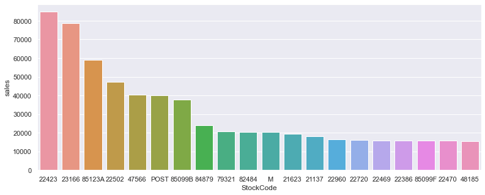

```python
# 1- get the top 20 of the highest selling products

df_top_20_product = df.groupby(['StockCode']).sum().sort_values(['sales'], ascending=False).head(20)
df_top_20_product = df_top_20_product.reset_index()
plt.subplots(figsize = (13, 5))
sns.barplot(df_top_20_product['StockCode'], df_top_20_product['sales'])
```

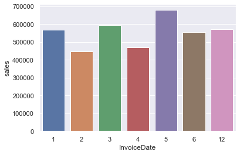

```python
# 3- get the sales by mouth
df_sales_by_month = df.groupby(pd.to_datetime(df['InvoiceDate']).dt.month).sum()
df_sales_by_month = df_sales_by_month.reset_index()
df_sales_by_month
sns.barplot(df_sales_by_month['InvoiceDate'], df_sales_by_month['sales'], estimator=sum);
```

2- this barplot shows the highest mouth in terms of sales which is May (the Fifth Month of the Year)

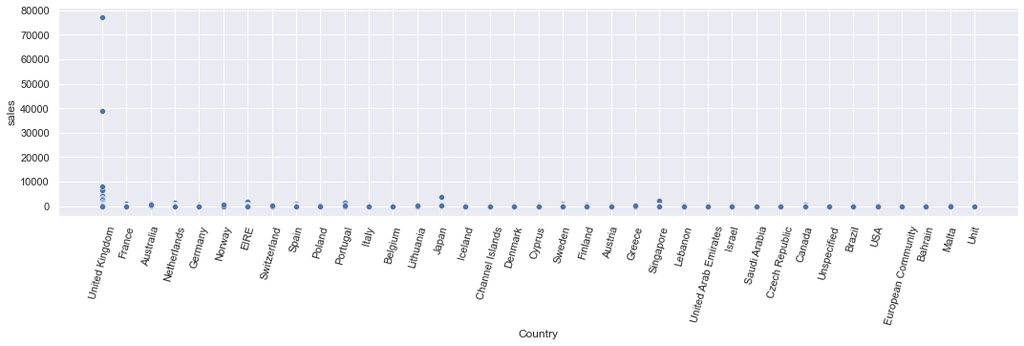

```python
plt.subplots(figsize = (18, 4))
plt.xticks(rotation=75)
scatterplot_1 = sns.scatterplot(df['Country'], df['sales']);
```

3- this shows the scatterplot for each country in terms of sales sales  
4- we have the highest Country in terms of sales is United Kindom

```python
df_sales_by_month['sales'].describe()
```

```
count         7.000000
mean     555567.391571
std       77925.121623
min      447137.350000
25%      512790.070500
50%      569445.040000
75%      584107.325000
max      678594.560000
Name: sales, dtype: float64
```

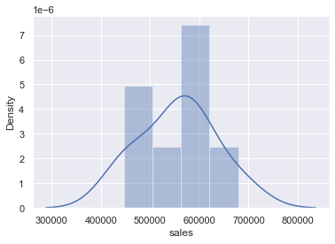

```python
sns.distplot(df_sales_by_month['sales'])
```

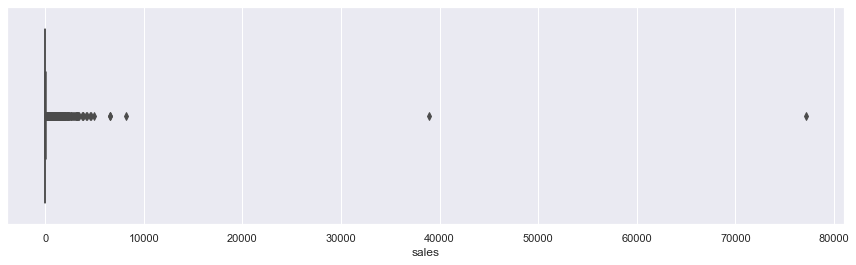

```python
plt.subplots(figsize = (15, 4))
sns.boxplot(df['sales'])
```

- The main data frame has a lot of extreme values so I grouped them by mouth